# Analyzing 100 Thieves Håvard "rain" Nygaard

In this python notebook we intend to analyze 100 Thieves' first signed player to their Counter Strike 2 roster.

The dataset we are working with was collected and compiled by myself because there didn't appear to be a readily available data set that gave any meaningful information, for example; hltv only contains the player's rating, kills, KAST, deaths, and a few other stats that don't deeply analyze the player round by round with any amount of context.

In order to gather the data I first wanted to find rain's best map in cs2 so far, then go round by round and record what each teams loadout was like, rain's specific loadout value, how many kills he got, where he got them, what weapons were used for each kill, if rain died, where he died if so, etc.

With more time, and resources, I can perform a much deeper analysis on any player and additionally I can create machine learning models that can predict the outcomes of rounds based on context to a certain degree of confidence, suggest the best loadouts to purchase in each economic situation based on historical data, as well as suggest the best areas of the map to try to force an opening kill.

But right now the goal is analyzing this data to find where rain excels the most recently, as well as to find where he performs worst to hopefully prevent in future games. Hopefully this analysis will assist in guiding 100 Thieves rain to the most optimal positions to have the most impact and round wins possible.

[figure not shown]

```python
import pandas as pd
import numpy as np
import matplotlib.pyplot as plt
import seaborn as sns
pd.set_option('display.max_columns', None)
```

## Map Information

The following is map information that can be found on hltv.org followed by a round by round dataset that I created by collecting information from each individual round.

Rain map stats:

Inferno: T rating - 1.18 | CT rating - 1.03 | Ovr - 1.10

Overpass: T rating - 0.83 | CT rating - 0.91 | Ovr - 0.87

Ancient: T rating - 1.26 | CT rating - 1.11 | Ovr - 1.18

Dust 2: T rating - 0.97 | CT rating - 1.06 | Ovr - 1.02

Mirage: T rating - 1.07 | CT rating - 0.98 | Ovr - 1.02

Nuke: T rating - 0.95 | CT rating - 0.99 | Ovr - 0.97

Train: T rating - 0.78 | CT rating - 0.81 | Ovr - 0.80

We see that rains best hltv rating appears to be on the map ancient, so we will analyze the last 5 matches on ancient (not including the recent performance at esl pro league due to the last minute nature of it for rain).

[figure not shown]

### BLAST Bounty 2025 Season 2

FaZe vs. BetBoom

2025-08-05 11:45

Map: Ancient

[figure not shown]

```python
pd.read_csv('rain data - betboom.csv').head()
```

|  | match_id | opp_team | round_num | round_winner_side | fp_side | round_end_reason | map_name | opp_round_type | fp_round_type | fp_equip_value | fp_kills | opening_kill | fp_kill_1_ location | fp_kill_2_ location | fp_kill_3_ location | fp_kill_4_ location | fp_kill_5_ location | fp_wep_kill_1 | fp_wep_kill_2 | fp_wep_kill_3 | fp_wep_kill_4 | fp_wep_kill_5 | fp_death_loc |
| --- | --- | --- | --- | --- | --- | --- | --- | --- | --- | --- | --- | --- | --- | --- | --- | --- | --- | --- | --- | --- | --- | --- | --- |
| 0 | 5 | betboom | 1 | t | t | kills | ancient | pistol | pistol | 750 | 1.0 | no | b_site | NaN | NaN | NaN | NaN | glock | NaN | NaN | NaN | NaN | survived |
| 1 | 5 | betboom | 2 | t | t | kills | ancient | low | full | 3500 | NaN | no | NaN | NaN | NaN | NaN | NaN | NaN | NaN | NaN | NaN | NaN | survived |
| 2 | 5 | betboom | 3 | ct | t | defuse | ancient | full | full | 4000 | 1.0 | no | cave | NaN | NaN | NaN | NaN | galil | NaN | NaN | NaN | NaN | b_site |
| 3 | 5 | betboom | 4 | t | t | kills | ancient | full | full | 4400 | 0.0 | no | NaN | NaN | NaN | NaN | NaN | NaN | NaN | NaN | NaN | NaN | b_ramp |
| 4 | 5 | betboom | 5 | ct | t | kills | ancient | half | full | 4900 | NaN | no | NaN | NaN | NaN | NaN | NaN | NaN | NaN | NaN | NaN | NaN | a_main |

### BLAST Bounty 2025 Season 2

FaZe vs. Virtus.pro

2025-08-09 06:10

Map: Ancient

[figure not shown]

```python
pd.read_csv('rain data - virtus.pro.csv').head()
```

|  | match_id | opp_team | round_num | round_winner_side | fp_side | round_end_reason | map_name | opp_round_type | fp_round_type | fp_equip_value | fp_kills | opening_kill | fp_kill_1_ location | fp_kill_2_ location | fp_kill_3_ location | fp_kill_4_ location | fp_kill_5_ location | fp_wep_kill_1 | fp_wep_kill_2 | fp_wep_kill_3 | fp_wep_kill_4 | fp_wep_kill_5 | fp_death_loc |
| --- | --- | --- | --- | --- | --- | --- | --- | --- | --- | --- | --- | --- | --- | --- | --- | --- | --- | --- | --- | --- | --- | --- | --- |
| 0 | 4 | virtuspro | 1 | ct | t | kills | ancient | pistol | pistol | 650 | NaN | no | NaN | NaN | NaN | NaN | NaN | NaN | NaN | NaN | NaN | NaN | b_site |
| 1 | 4 | virtuspro | 2 | ct | t | kills | ancient | half | low | 0 | NaN | no | NaN | NaN | NaN | NaN | NaN | NaN | NaN | NaN | NaN | NaN | cat |
| 2 | 4 | virtuspro | 3 | ct | t | defuse | ancient | full | full | 4400 | NaN | no | NaN | NaN | NaN | NaN | NaN | NaN | NaN | NaN | NaN | NaN | b_ramp |
| 3 | 4 | virtuspro | 4 | ct | t | defuse | ancient | full | low | 1850 | NaN | no | NaN | NaN | NaN | NaN | NaN | NaN | NaN | NaN | NaN | NaN | a_site |
| 4 | 4 | virtuspro | 5 | t | t | kills | ancient | full | full | 4800 | 1.0 | no | cat | NaN | NaN | NaN | NaN | ak-47 | NaN | NaN | NaN | NaN | cat |

### FISSURE Playground 2

FaZe vs. 3DMAX

2025-09-14 01:00

Map: Ancient

[figure not shown]

```python
pd.read_csv('rain data - 3DMAX.csv').head()
```

|  | match_id | opp_team | round_num | round_winner_side | fp_side | round_end_reason | map_name | opp_round_type | fp_round_type | fp_equip_value | fp_kills | opening_kill | fp_kill_1_ location | fp_kill_2_ location | fp_kill_3_ location | fp_kill_4_ location | fp_kill_5_ location | fp_wep_kill_1 | fp_wep_kill_2 | fp_wep_kill_3 | fp_wep_kill_4 | fp_wep_kill_5 | fp_death_loc |
| --- | --- | --- | --- | --- | --- | --- | --- | --- | --- | --- | --- | --- | --- | --- | --- | --- | --- | --- | --- | --- | --- | --- | --- |
| 0 | 3 | 3dmax | 1 | t | t | bomb | ancient | pistol | pistol | 900 | 2.0 | no | b_site | b_site | NaN | NaN | NaN | glock | glock | NaN | NaN | NaN | cat |
| 1 | 3 | 3dmax | 2 | t | t | kills | ancient | half | full | 4200 | 1.0 | no | cave | NaN | NaN | NaN | NaN | ak-47 | NaN | NaN | NaN | NaN | survived |
| 2 | 3 | 3dmax | 3 | t | t | kills | ancient | low | full | 4900 | 1.0 | no | b_site | NaN | NaN | NaN | NaN | ak-47 | NaN | NaN | NaN | NaN | survived |
| 3 | 3 | 3dmax | 4 | ct | t | defuse | ancient | full | full | 4900 | NaN | no | NaN | NaN | NaN | NaN | NaN | NaN | NaN | NaN | NaN | NaN | survived |
| 4 | 3 | 3dmax | 5 | t | t | kills | ancient | full | full | 4900 | 1.0 | no | cat | NaN | NaN | NaN | NaN | ak-47 | NaN | NaN | NaN | NaN | survived |

### FISSURE Playground 2

FaZe vs. The MongolZ

2025-09-16 06:05

Map: Ancient

[figure not shown]

```python
pd.read_csv("rain data - mongolz.csv").head()
```

|  | match_id | opp_team | round_num | round_winner_side | fp_side | round_end_reason | map_name | opp_round_type | fp_round_type | fp_equip_value | fp_kills | opening_kill | fp_kill_1_ location | fp_kill_2_ location | fp_kill_3_ location | fp_kill_4_ location | fp_kill_5_ location | fp_wep_kill_1 | fp_wep_kill_2 | fp_wep_kill_3 | fp_wep_kill_4 | fp_wep_kill_5 | fp_death_loc |
| --- | --- | --- | --- | --- | --- | --- | --- | --- | --- | --- | --- | --- | --- | --- | --- | --- | --- | --- | --- | --- | --- | --- | --- |
| 0 | 1 | mongolz | 1 | t | ct | bomb | ancient | pistol | pistol | 650 | 1.0 | no | a_site | NaN | NaN | NaN | NaN | p2000 | NaN | NaN | NaN | NaN | a_site |
| 1 | 1 | mongolz | 2 | t | ct | bomb | ancient | full | half | 2600 | NaN | no | NaN | NaN | NaN | NaN | NaN | NaN | NaN | NaN | NaN | NaN | survived |
| 2 | 1 | mongolz | 3 | t | ct | kills | ancient | full | half | 2300 | NaN | no | NaN | NaN | NaN | NaN | NaN | NaN | NaN | NaN | NaN | NaN | mid |
| 3 | 1 | mongolz | 4 | t | ct | kills | ancient | full | full | 5000 | 1.0 | yes | cat | NaN | NaN | NaN | NaN | m4a4 | NaN | NaN | NaN | NaN | a_site |
| 4 | 1 | mongolz | 5 | t | ct | bomb | ancient | full | half | 2150 | 1.0 | no | cat | NaN | NaN | NaN | NaN | deagle | NaN | NaN | NaN | NaN | survived |

### FISSURE Playground 2

FaZe vs. Liquid

2025-09-17 02:20

Map: Ancient

[figure not shown]

```python
pd.read_csv("rain data - liquid.csv").head()
```

|  | match_id | opp_team | round_num | round_winner_side | fp_side | round_end_reason | map_name | opp_round_type | fp_round_type | fp_equip_value | fp_kills | opening_kill | fp_kill_1_ location | fp_kill_2_ location | fp_kill_3_ location | fp_kill_4_ location | fp_kill_5_ location | fp_wep_kill_1 | fp_wep_kill_2 | fp_wep_kill_3 | fp_wep_kill_4 | fp_wep_kill_5 | fp_death_loc |
| --- | --- | --- | --- | --- | --- | --- | --- | --- | --- | --- | --- | --- | --- | --- | --- | --- | --- | --- | --- | --- | --- | --- | --- |
| 0 | 2 | liquid | 1 | t | ct | kills | ancient | pistol | pistol | 650 | NaN | no | NaN | NaN | NaN | NaN | NaN | NaN | NaN | NaN | NaN | NaN | cat |
| 1 | 2 | liquid | 2 | t | ct | kills | ancient | half | low | 0 | NaN | no | NaN | NaN | NaN | NaN | NaN | NaN | NaN | NaN | NaN | NaN | a_site |
| 2 | 2 | liquid | 3 | ct | ct | kills | ancient | full | full | 4700 | 3.0 | yes | cat | cat | cat | NaN | NaN | m4a4 | m4a4 | m4a4 | NaN | NaN | survived |
| 3 | 2 | liquid | 4 | t | ct | kills | ancient | full | full | 5200 | NaN | no | NaN | NaN | NaN | NaN | NaN | NaN | NaN | NaN | NaN | NaN | cave |
| 4 | 2 | liquid | 5 | t | ct | bomb | ancient | full | full | 5000 | NaN | no | NaN | NaN | NaN | NaN | NaN | NaN | NaN | NaN | NaN | NaN | b_site |

## Importing our Data + Immediate Insights

Here we will import our csvs and draw immediately apparent insights about rains performances on these games of ancient.

```python
rain_data = pd.concat([
    pd.read_csv("rain data - mongolz.csv"),
    pd.read_csv("rain data - liquid.csv"),
    pd.read_csv("rain data - 3DMAX.csv"),
    pd.read_csv("rain data - virtus.pro.csv"),
    pd.read_csv("rain data - betboom.csv")], ignore_index=True)
```

```python
rain_data.describe()
```

|  | match_id | round_num | fp_equip_value | fp_kills | fp_kill_5_ location | fp_wep_kill_5 |
| --- | --- | --- | --- | --- | --- | --- |
| count | 94.000000 | 94.000000 | 94.000000 | 51.000000 | 0.0 | 0.0 |
| mean | 3.053191 | 10.000000 | 3836.702128 | 1.431373 | NaN | NaN |
| std | 1.424570 | 5.622535 | 1687.145830 | 0.728146 | NaN | NaN |
| min | 1.000000 | 1.000000 | 0.000000 | 0.000000 | NaN | NaN |
| 25% | 2.000000 | 5.000000 | 3062.500000 | 1.000000 | NaN | NaN |
| 50% | 3.000000 | 10.000000 | 4700.000000 | 1.000000 | NaN | NaN |
| 75% | 4.000000 | 14.750000 | 4900.000000 | 2.000000 | NaN | NaN |
| max | 5.000000 | 22.000000 | 5600.000000 | 4.000000 | NaN | NaN |

The average value of rain's equipment is 3836 with a standard deviation of 1687.

```python
kill_deaths = rain_data.groupby(['match_id','opp_team']).agg({'fp_kills': 'sum', 'fp_death_loc': lambda x: x[x != 'survived'].count()})
kill_deaths['K_D_Ratio'] = kill_deaths['fp_kills'] / kill_deaths['fp_death_loc']
kill_deaths.reset_index(inplace=True)
kill_deaths
```

|  | match_id | opp_team | fp_kills | fp_death_loc | K_D_Ratio |
| --- | --- | --- | --- | --- | --- |
| 0 | 1 | mongolz | 15.0 | 13 | 1.153846 |
| 1 | 2 | liquid | 15.0 | 14 | 1.071429 |
| 2 | 3 | 3dmax | 19.0 | 9 | 2.111111 |
| 3 | 4 | virtuspro | 10.0 | 12 | 0.833333 |
| 4 | 5 | betboom | 14.0 | 9 | 1.555556 |

```python
rain_data['fp_kills'].mean()
```

```
np.float64(1.4313725490196079)
```

```python
kill_deaths.describe()
```

|  | match_id | fp_kills | fp_death_loc | K_D_Ratio |
| --- | --- | --- | --- | --- |
| count | 5.000000 | 5.000000 | 5.000000 | 5.000000 |
| mean | 3.000000 | 14.600000 | 11.400000 | 1.345055 |
| std | 1.581139 | 3.209361 | 2.302173 | 0.501110 |
| min | 1.000000 | 10.000000 | 9.000000 | 0.833333 |
| 25% | 2.000000 | 14.000000 | 9.000000 | 1.071429 |
| 50% | 3.000000 | 15.000000 | 12.000000 | 1.153846 |
| 75% | 4.000000 | 15.000000 | 13.000000 | 1.555556 |
| max | 5.000000 | 19.000000 | 14.000000 | 2.111111 |

We see above that rain generally has a solid positive kd on ancient in these 5 games we are going to analyze further he averages 0.77 kills per round, with a k/d of 1.345 averaging 14.6 kills a game and 11.4 deaths with a standard deviation of 3.2 and 2.3 respectively. With rain's best performance being against 3DMAX and worst against Virtus.pro.

```python
weapon_columns = ['fp_wep_kill_1',	'fp_wep_kill_2',	'fp_wep_kill_3',	'fp_wep_kill_4', 'fp_wep_kill_5']
all_weapons = pd.Series(dtype='object')
for col in weapon_columns:
    all_weapons = pd.concat([all_weapons, rain_data[col].dropna()])
all_weapons = all_weapons[all_weapons != 'no_kill']
top_3_weapons = all_weapons.value_counts().head(3)
top_3_weapons
```

```
ak-47    40
m4a4     10
glock     6
Name: count, dtype: int64
```

Immediately we can also tell that rain's best weapon is the ak-47 by far as it's 4x more prevalent in his kill history in these 5 maps than the runner up, the m4a4.

## Preprocessing + Feature Engineering

In the following cells we are going to be performing some feature engineering and data imputation on the rain_data data set.

```python
#create a new column 'fp_wins_round' that is True if 'fp_side' equals 'round_winner_side', otherwise False
rain_data['fp_wins_round'] = (rain_data['fp_side'] == rain_data['round_winner_side']).astype(bool)

rain_data[['fp_side', 'round_winner_side', 'fp_wins_round']].head()
```

|  | fp_side | round_winner_side | fp_wins_round |
| --- | --- | --- | --- |
| 0 | ct | t | False |
| 1 | ct | t | False |
| 2 | ct | t | False |
| 3 | ct | t | False |
| 4 | ct | t | False |

```python
#create a new column 'fp_died' where it is true is if 'fp_death_loc' is not 'survived'
rain_data['fp_died'] = rain_data['fp_death_loc'].apply(lambda x: x != 'survived')
rain_data[['fp_death_loc', 'fp_died']].head()
```

|  | fp_death_loc | fp_died |
| --- | --- | --- |
| 0 | a_site | True |
| 1 | survived | False |
| 2 | mid | True |
| 3 | a_site | True |
| 4 | survived | False |

```python
#fill missing values in 'fp_kills' column with 0
rain_data['fp_kills'] = rain_data['fp_kills'].fillna(0)
rain_data['fp_kills'].head()
#fill missing values in 'fp_kill_1_ location' column with 'no_kill'
rain_data['fp_kill_1_location'] = rain_data['fp_kill_1_ location'].fillna('no_kill')
#fill missing values in 'fp_kill_2_ location' column with 'no_kill'
rain_data['fp_kill_2_location'] = rain_data['fp_kill_2_ location'].fillna('no_kill')
#fill missing values in 'fp_kill_3_ location' column with 'no_kill'
rain_data['fp_kill_3_location'] = rain_data['fp_kill_3_ location'].fillna('no_kill')
#fill missing values in 'fp_kill_4_ location' column with 'no_kill'
rain_data['fp_kill_4_location'] = rain_data['fp_kill_4_ location'].fillna('no_kill')
#fill missing values in 'fp_kill_5_ location' column with 'no_kill'
rain_data['fp_kill_5_location'] = rain_data['fp_kill_5_ location'].fillna('no_kill')
```

```python
rain_data
```

|  | match_id | opp_team | round_num | round_winner_side | fp_side | round_end_reason | map_name | opp_round_type | fp_round_type | fp_equip_value | fp_kills | opening_kill | fp_kill_1_ location | fp_kill_2_ location | fp_kill_3_ location | fp_kill_4_ location | fp_kill_5_ location | fp_wep_kill_1 | fp_wep_kill_2 | fp_wep_kill_3 | fp_wep_kill_4 | fp_wep_kill_5 | fp_death_loc | fp_wins_round | fp_died | fp_kill_1_location | fp_kill_2_location | fp_kill_3_location | fp_kill_4_location | … |
| --- | --- | --- | --- | --- | --- | --- | --- | --- | --- | --- | --- | --- | --- | --- | --- | --- | --- | --- | --- | --- | --- | --- | --- | --- | --- | --- | --- | --- | --- | --- |
| 0 | 1 | mongolz | 1 | t | ct | bomb | ancient | pistol | pistol | 650 | 1.0 | no | a_site | NaN | NaN | NaN | NaN | p2000 | NaN | NaN | NaN | NaN | a_site | False | True | a_site | no_kill | no_kill | no_kill | … |
| 1 | 1 | mongolz | 2 | t | ct | bomb | ancient | full | half | 2600 | 0.0 | no | NaN | NaN | NaN | NaN | NaN | NaN | NaN | NaN | NaN | NaN | survived | False | False | no_kill | no_kill | no_kill | no_kill | … |
| 2 | 1 | mongolz | 3 | t | ct | kills | ancient | full | half | 2300 | 0.0 | no | NaN | NaN | NaN | NaN | NaN | NaN | NaN | NaN | NaN | NaN | mid | False | True | no_kill | no_kill | no_kill | no_kill | … |
| 3 | 1 | mongolz | 4 | t | ct | kills | ancient | full | full | 5000 | 1.0 | yes | cat | NaN | NaN | NaN | NaN | m4a4 | NaN | NaN | NaN | NaN | a_site | False | True | cat | no_kill | no_kill | no_kill | … |
| 4 | 1 | mongolz | 5 | t | ct | bomb | ancient | full | half | 2150 | 1.0 | no | cat | NaN | NaN | NaN | NaN | deagle | NaN | NaN | NaN | NaN | survived | False | False | cat | no_kill | no_kill | no_kill | … |
| ... | ... | ... | ... | ... | ... | ... | ... | ... | ... | ... | ... | ... | ... | ... | ... | ... | ... | ... | ... | ... | ... | ... | ... | ... | ... | ... | ... | ... | ... | … |
| 89 | 5 | betboom | 15 | t | ct | bomb | ancient | full | full | 5000 | 1.0 | no | cat | NaN | NaN | NaN | NaN | m4a4 | NaN | NaN | NaN | NaN | survived | False | False | cat | no_kill | no_kill | no_kill | … |
| 90 | 5 | betboom | 16 | t | ct | kills | ancient | full | low | 4100 | 2.0 | yes | cave | a_site | NaN | NaN | NaN | ak-47 | ak-47 | NaN | NaN | NaN | a_site | False | True | cave | a_site | no_kill | no_kill | … |
| 91 | 5 | betboom | 17 | ct | ct | kills | ancient | full | full | 4550 | 0.0 | no | NaN | NaN | NaN | NaN | NaN | NaN | NaN | NaN | NaN | NaN | survived | True | False | no_kill | no_kill | no_kill | no_kill | … |
| 92 | 5 | betboom | 18 | ct | ct | defuse | ancient | low | full | 5600 | 0.0 | no | NaN | NaN | NaN | NaN | NaN | NaN | NaN | NaN | NaN | NaN | red_room | True | True | no_kill | no_kill | no_kill | no_kill | … |
| 93 | 5 | betboom | 19 | ct | ct | kills | ancient | half | full | 5400 | 1.0 | no | b_site | NaN | NaN | NaN | NaN | ak-47 | NaN | NaN | NaN | NaN | survived | True | False | b_site | no_kill | no_kill | no_kill | … |

94 rows × 30 columns

```python
#fill missing values in each of the 'fp_wep_kill_x' columns with 'no_kill'
rain_data['fp_wep_kill_1'] = rain_data['fp_wep_kill_1'].fillna('no_kill')
rain_data['fp_wep_kill_2'] = rain_data['fp_wep_kill_2'].fillna('no_kill')
rain_data['fp_wep_kill_3'] = rain_data['fp_wep_kill_3'].fillna('no_kill')
rain_data['fp_wep_kill_4'] = rain_data['fp_wep_kill_4'].fillna('no_kill')
rain_data['fp_wep_kill_5'] = rain_data['fp_wep_kill_5'].fillna('no_kill')
```

```python
rain_data = rain_data.drop(columns=['fp_kill_1_ location', 'fp_kill_2_ location', 'fp_kill_3_ location', 'fp_kill_4_ location', 'fp_kill_5_ location'])
```

```python
#change datatype of opening_kill to boolean where 1 is True and 0 is False
rain_data['opening_kill'] = rain_data['opening_kill'].astype(bool)
```

```python
rain_data.describe()
```

|  | match_id | round_num | fp_equip_value | fp_kills |
| --- | --- | --- | --- | --- |
| count | 94.000000 | 94.000000 | 94.000000 | 94.000000 |
| mean | 3.053191 | 10.000000 | 3836.702128 | 0.776596 |
| std | 1.424570 | 5.622535 | 1687.145830 | 0.893877 |
| min | 1.000000 | 1.000000 | 0.000000 | 0.000000 |
| 25% | 2.000000 | 5.000000 | 3062.500000 | 0.000000 |
| 50% | 3.000000 | 10.000000 | 4700.000000 | 1.000000 |
| 75% | 4.000000 | 14.750000 | 4900.000000 | 1.000000 |
| max | 5.000000 | 22.000000 | 5600.000000 | 4.000000 |

```python
rain_data.columns
```

```
Index(['match_id', 'opp_team', 'round_num', 'round_winner_side', 'fp_side',
       'round_end_reason', 'map_name', 'opp_round_type', 'fp_round_type',
       'fp_equip_value', 'fp_kills', 'opening_kill', 'fp_wep_kill_1',
       'fp_wep_kill_2', 'fp_wep_kill_3', 'fp_wep_kill_4', 'fp_wep_kill_5',
       'fp_death_loc', 'fp_wins_round', 'fp_died', 'fp_kill_1_location',
       'fp_kill_2_location', 'fp_kill_3_location', 'fp_kill_4_location',
       'fp_kill_5_location'],
      dtype='object')
```

```python
#creating a new column FP_Kills_Last_3_Rounds, Sum of fp_kills from the last 3 rounds (N-1 to N-3).Captures the player's short-term form and confidence. A player on a hot streak might be more aggressive. but only include rounds that are from the same match id
rain_data['FP_Kills_Last_3_Rounds'] = 0
for i in range(len(rain_data)):
    match_id = rain_data.loc[i, 'match_id']
    round_num = rain_data.loc[i, 'round_num']
    last_3_rounds = rain_data[(rain_data['match_id'] == match_id) & (rain_data['round_num'] < round_num) & (rain_data['round_num'] >= round_num - 3)]
    rain_data.loc[i, 'FP_Kills_Last_3_Rounds'] = last_3_rounds['fp_kills'].sum()
rain_data[['match_id', 'round_num', 'fp_kills', 'FP_Kills_Last_3_Rounds']].head(10)
```

|  | match_id | round_num | fp_kills | FP_Kills_Last_3_Rounds |
| --- | --- | --- | --- | --- |
| 0 | 1 | 1 | 1.0 | 0 |
| 1 | 1 | 2 | 0.0 | 1 |
| 2 | 1 | 3 | 0.0 | 1 |
| 3 | 1 | 4 | 1.0 | 1 |
| 4 | 1 | 5 | 1.0 | 1 |
| 5 | 1 | 6 | 0.0 | 2 |
| 6 | 1 | 7 | 0.0 | 2 |
| 7 | 1 | 8 | 0.0 | 1 |
| 8 | 1 | 9 | 1.0 | 0 |
| 9 | 1 | 10 | 2.0 | 1 |

```python
#creating a new column fp_team_win_streak, counts the number of consecutive rounds the player's team has won up to the current round within the same match
rain_data['fp_team_win_streak'] = 0
for i in range(len(rain_data)):
    match_id = rain_data.loc[i, 'match_id']
    round_num = rain_data.loc[i, 'round_num']
    fp_side = rain_data.loc[i, 'fp_side']

    win_streak = 0
    for j in range(round_num - 1, 0, -1):
        previous_round = rain_data[(rain_data['match_id'] == match_id) & (rain_data['round_num'] == j)]
        if not previous_round.empty:
            if previous_round.iloc[0]['round_winner_side'] == fp_side:
                win_streak += 1
            else:
                break
    rain_data.loc[i, 'fp_team_win_streak'] = win_streak
rain_data[['match_id', 'round_num', 'fp_side', 'round_winner_side', 'fp_team_win_streak']].head(10)
```

|  | match_id | round_num | fp_side | round_winner_side | fp_team_win_streak |
| --- | --- | --- | --- | --- | --- |
| 0 | 1 | 1 | ct | t | 0 |
| 1 | 1 | 2 | ct | t | 0 |
| 2 | 1 | 3 | ct | t | 0 |
| 3 | 1 | 4 | ct | t | 0 |
| 4 | 1 | 5 | ct | t | 0 |
| 5 | 1 | 6 | ct | t | 0 |
| 6 | 1 | 7 | ct | t | 0 |
| 7 | 1 | 8 | ct | ct | 0 |
| 8 | 1 | 9 | ct | ct | 1 |
| 9 | 1 | 10 | ct | t | 2 |

```python
#creating a new column opp_team_win_streak, counts the number of consecutive rounds the opposing team has won up to the current round within the same match
rain_data['opp_team_win_streak'] = 0
for i in range(len(rain_data)):
    match_id = rain_data.loc[i, 'match_id']
    round_num = rain_data.loc[i, 'round_num']
    fp_side = rain_data.loc[i, 'fp_side']
    opp_side = 'ct' if fp_side == 't' else 't'

    win_streak = 0
    for j in range(round_num - 1, 0, -1):
        previous_round = rain_data[(rain_data['match_id'] == match_id) & (rain_data['round_num'] == j)]
        if not previous_round.empty:
            if previous_round.iloc[0]['round_winner_side'] == opp_side:
                win_streak += 1
            else:
                break
    rain_data.loc[i, 'opp_team_win_streak'] = win_streak
rain_data[['match_id', 'round_num', 'fp_side', 'round_winner_side', 'opp_team_win_streak']].head(10)
```

|  | match_id | round_num | fp_side | round_winner_side | opp_team_win_streak |
| --- | --- | --- | --- | --- | --- |
| 0 | 1 | 1 | ct | t | 0 |
| 1 | 1 | 2 | ct | t | 1 |
| 2 | 1 | 3 | ct | t | 2 |
| 3 | 1 | 4 | ct | t | 3 |
| 4 | 1 | 5 | ct | t | 4 |
| 5 | 1 | 6 | ct | t | 5 |
| 6 | 1 | 7 | ct | t | 6 |
| 7 | 1 | 8 | ct | ct | 7 |
| 8 | 1 | 9 | ct | ct | 0 |
| 9 | 1 | 10 | ct | t | 0 |

```python
rain_data.info()
```

```
<class 'pandas.core.frame.DataFrame'>
RangeIndex: 94 entries, 0 to 93
Data columns (total 28 columns):
 #   Column                  Non-Null Count  Dtype
---  ------                  --------------  -----
 0   match_id                94 non-null     int64
 1   opp_team                94 non-null     object
 2   round_num               94 non-null     int64
 3   round_winner_side       94 non-null     object
 4   fp_side                 94 non-null     object
 5   round_end_reason        94 non-null     object
 6   map_name                94 non-null     object
 7   opp_round_type          94 non-null     object
 8   fp_round_type           94 non-null     object
 9   fp_equip_value          94 non-null     int64
```

[output cut: 20 more lines]

## Analysis

Now that we have our features we can analyze rain more in depth and draw much more meaningful and potentially, previously hidden insights.

### Consistency and Momentum

The first thing I want to analyze is rains consistency and momentum. How reliable is he when the odds are against him? Is he a an unchanging rock that performs no matter the circumstances? Or does he crumble under the pressure? How well does he carry his momentum between rounds? Is he able to snowball when he enters the flow state and can't be stopped? Let's find out.

#### Consistency

We are going to first look at whether or not rain's performance is personally affected when his opponent has momentum, is he able to step up or crumble under pressure?

```python
streak_performance = rain_data.groupby('opp_team_win_streak')['fp_kills'].mean().reset_index()
streak_performance.columns = ['Opponent_Streak_Length', 'FP_Average_Kills']

print("--- FP Average Kills vs. Opponent Win Streak ---")
print(streak_performance)

# --- 3. Binning for Clearer Analysis (Optional but recommended) ---
# If you have a long tail of streak lengths (e.g., streaks of 7, 8, 9...),
# it's best to group them into an '4+ Streak' category for statistical robustness.
bins = [-1, 0, 1, 2, 3, rain_data['opp_team_win_streak'].max()]
labels = ['Streak_0', 'Streak_1', 'Streak_2', 'Streak_3', 'Streak_4+']

rain_data['Streak_Group'] = pd.cut(
    rain_data['opp_team_win_streak'],
    bins=bins,
    labels=labels,
    right=True,
    include_lowest=True
)

binned_performance = rain_data.groupby('Streak_Group', observed=False)['fp_kills'].agg(['mean', 'count']).reset_index()
binned_performance.columns = ['Opponent_Streak_Group', 'FP_Average_Kills', 'Round_Count']

print("\n--- FP Average Kills vs. Binned Opponent Win Streak ---")
print(binned_performance)
```

```
--- FP Average Kills vs. Opponent Win Streak ---
   Opponent_Streak_Length  FP_Average_Kills
0                       0          0.938776
1                       1          0.705882
2                       2          0.875000
3                       3          0.250000
4                       4          0.500000
5                       5          0.250000
6                       6          0.750000
7                       7          0.333333
8                       8          0.000000

--- FP Average Kills vs. Binned Opponent Win Streak ---
  Opponent_Streak_Group  FP_Average_Kills  Round_Count
0              Streak_0          0.938776           49
1              Streak_1          0.705882           17
2              Streak_2          0.875000            8
3              Streak_3          0.250000            4
4             Streak_4+          0.437500           16
```

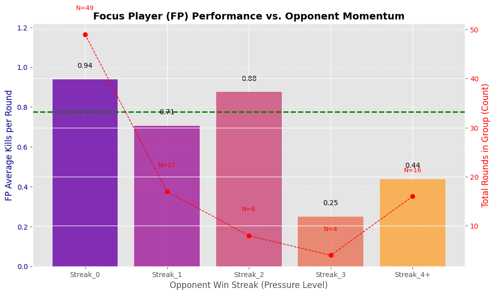

```
The colored bars show the FP's average kills against each opponent streak group (0,1,2,3,4+), and the red line/dots show the number of rounds used for that average (sample size).
And the green dashed line indicates the FP's overall average kills per round (0.777). This visualization helps assess how the FP performs under varying levels of opponent momentum pressure.
```

```python
plt.style.use('ggplot')

fig, ax1 = plt.subplots(figsize=(10, 6))

colors = plt.cm.plasma(np.linspace(0.2, 0.8, len(binned_performance)))

bars = ax1.bar(
    binned_performance['Opponent_Streak_Group'],
    binned_performance['FP_Average_Kills'],
    color=colors,
    alpha=0.8,
    label='Average Kills (per Round)'
)

for bar in bars:
    yval = bar.get_height()
    ax1.text(bar.get_x() + bar.get_width()/2, yval + 0.05,
             f'{yval:.2f}', ha='center', va='bottom', fontsize=10, color='black')

ax1.axhline(
    0.777, #0.777 is rain's average kills per round
    color='green',
    linestyle='--',
    linewidth=2,
    label=f'FP Overall Average (0.777)'
)

ax1.set_ylim(0, binned_performance['FP_Average_Kills'].max() * 1.3)
ax1.set_xlabel('Opponent Win Streak (Pressure Level)', fontsize=12)
ax1.set_ylabel('FP Average Kills per Round', color='darkblue', fontsize=12)
ax1.tick_params(axis='y', labelcolor='darkblue')
ax1.grid(axis='y', linestyle='--', alpha=0.6)

ax2 = ax1.twinx()
ax2.plot(
    binned_performance['Opponent_Streak_Group'],
    binned_performance['Round_Count'],
    color='red',
    marker='o',
    linestyle='--',
    linewidth=1,
    label='Total Rounds in Group'
)

ax2.set_ylabel('Total Rounds in Group (Count)', color='red', fontsize=12)
ax2.tick_params(axis='y', labelcolor='red')

for i, count in enumerate(binned_performance['Round_Count']):
    ax2.text(i, count + 5, f'N={count}', ha='center', color='red', fontsize=9)


plt.title(
    "Focus Player (FP) Performance vs. Opponent Momentum",
    fontsize=14,
    fontweight='bold'
)
fig.tight_layout()
plt.show()

print("The colored bars show the FP's average kills against each opponent streak group (0,1,2,3,4+), and the red line/dots show the number of rounds used for that average (sample size).")
print("And the green dashed line indicates the FP's overall average kills per round (0.777). This visualization helps assess how the FP performs under varying levels of opponent momentum pressure.")
```

So as we see above from the visualization rain is able to keep his perfomance, kill-wise, consistent as long as the opponent's round streak remains under 3 rounds. As we get into the deeper opponent round streaks 3 and above we see a steep drop off in consistency, which indicates reliability until the opponents have won 3 rounds in a row in which he seems to lose momentum and potentially confidence to get kills.

#### Momentum

Now that we looked at how rain deals with his opposition's momentum, let's see how he deals with his own? Is he a momentum based player that can go on a hot streak and enter a "flow-state"? Or does he have a stable unmoving performance (kill-wise) even when the kills start rolling in?

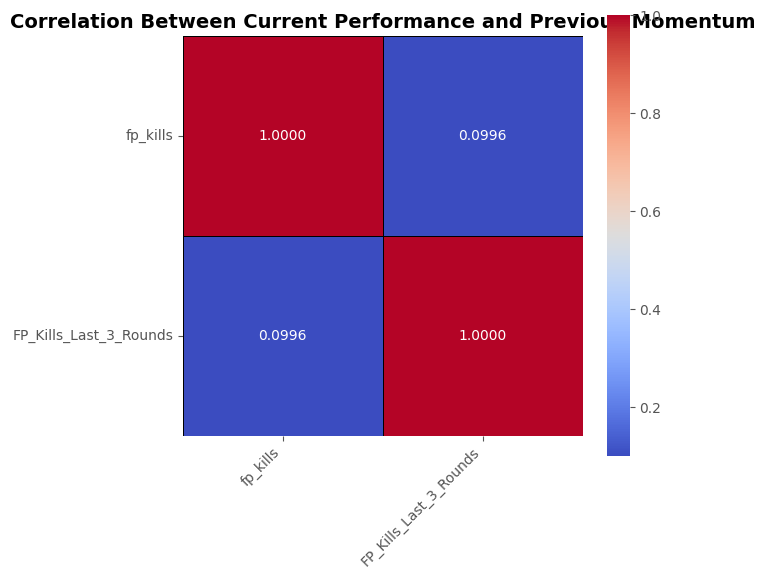

```
--- Correlation Analysis ---
Correlation (r) between current kills and kills in last 3 rounds: 0.0996
Interpretation: The correlation is WEAK or negligible.
This suggests the player's performance in any given round is largely INDEPENDENT of their immediate historical performance.
```

```python
correlation_data = rain_data[['fp_kills', 'FP_Kills_Last_3_Rounds']]

correlation_matrix = correlation_data.corr()

plt.figure(figsize=(7, 6))

sns.heatmap(
    correlation_matrix,
    annot=True,
    fmt='.4f',
    cmap='coolwarm',
    cbar=True,
    linewidths=.5,
    linecolor='black',
    square=True
)

plt.title(
    'Correlation Between Current Performance and Previous Momentum',
    fontsize=14,
    fontweight='bold'
)
plt.xticks(rotation=45, ha='right', fontsize=10)
plt.yticks(rotation=0, fontsize=10)
plt.tight_layout()
plt.show()

momentum_correlation = correlation_matrix.loc['fp_kills', 'FP_Kills_Last_3_Rounds']

print("\n--- Correlation Analysis ---")
print(f"Correlation (r) between current kills and kills in last 3 rounds: {momentum_correlation:.4f}")

if momentum_correlation > 0.3:
    print("Interpretation: There is a POSITIVE and MODERATE-TO-STRONG correlation.")
    print("This suggests the player is MOMENTUM-DEPENDENT: high kills in previous rounds lead to high kills in the current round.")
elif momentum_correlation < -0.3:
    print("Interpretation: There is a NEGATIVE and MODERATE-TO-STRONG correlation.")
    print("This suggests a REVERSION TO THE MEAN: high kills previously might indicate they are due for a lower-kill round (or vice-versa).")
else:
    print("Interpretation: The correlation is WEAK or negligible.")
    print("This suggests the player's performance in any given round is largely INDEPENDENT of their immediate historical performance.")
```

As the statement above concluded, rain appears to be able to perform and get kills completely independent of his previous rounds performance indicating that his kills come from consistency and not due to him "heating up".

### Economic and Contextual Performance

In this section we will focus on rain's performance changes dependent on his team's and opponent's money situation. Is he able to perform as well under poor economic conditions as he does under ideal ones? Or is he only a sunshine shooter?

#### Low Buy/Full Buy Kill Efficiency

Here we will analyze the context of rain's kills, whether he got most of his kills against low buys, half buys, full buys or an even distribution of them.

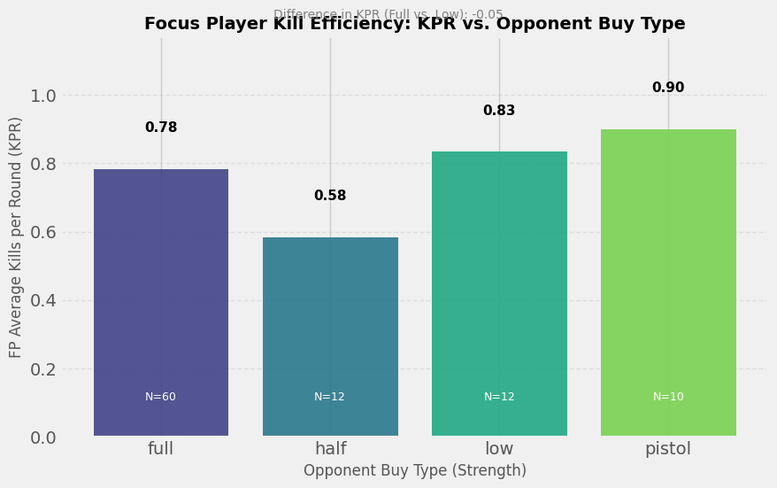

```
Average KPR against 'full' buy opponents: 0.78
Average KPR against 'low' buy opponents: 0.83
```

```python
# Group the data by the opponent's round type and calculate the mean kills
efficiency_data = rain_data.groupby('opp_round_type')['fp_kills'].agg(['mean', 'count']).reset_index()
efficiency_data.columns = ['Opponent_Round_Type', 'FP_Average_Kills', 'Round_Count']

# Define the order of the round types (from strongest opposition to weakest)
round_order = ['full', 'half', 'low', 'pistol']
efficiency_data['Opponent_Round_Type'] = pd.Categorical(
    efficiency_data['Opponent_Round_Type'],
    categories=round_order,
    ordered=True
)
efficiency_data = efficiency_data.sort_values('Opponent_Round_Type')


# --- 3. Visualization: Bar Chart of KPR by Opponent Round Type ---

plt.style.use('fivethirtyeight')
fig, ax = plt.subplots(figsize=(9, 6))

# Use a colormap, making the "full" buy rounds visually distinct if possible
colors = sns.color_palette("viridis", len(efficiency_data))

# Create the Bar Chart
bars = ax.bar(
    efficiency_data['Opponent_Round_Type'],
    efficiency_data['FP_Average_Kills'],
    color=colors,
    alpha=0.9
)

# Add value labels (KPR) on top of the bars and round count (N) inside
for i, bar in enumerate(bars):
    yval = bar.get_height()
    N = efficiency_data['Round_Count'].iloc[i]

    # KPR Label (on top)
    ax.text(bar.get_x() + bar.get_width()/2, yval + 0.1,
            f'{yval:.2f}', ha='center', va='bottom', fontsize=11, color='black', fontweight='bold')

    # Round Count Label (inside)
    ax.text(bar.get_x() + bar.get_width()/2, 0.1,
            f'N={N}', ha='center', va='bottom', fontsize=9, color='white')


# --- 4. Final Touches and Interpretation ---

# Extract average kills for Full and Low for the key comparison
full_kpr = efficiency_data[efficiency_data['Opponent_Round_Type'] == 'full']['FP_Average_Kills'].iloc[0]
low_kpr = efficiency_data[efficiency_data['Opponent_Round_Type'] == 'low']['FP_Average_Kills'].iloc[0]
kpr_difference = full_kpr - low_kpr

ax.set_ylim(0, efficiency_data['FP_Average_Kills'].max() * 1.3)
ax.set_xlabel('Opponent Buy Type (Strength)', fontsize=12)
ax.set_ylabel('FP Average Kills per Round (KPR)', fontsize=12)

# Highlight the most important comparison
plt.title(
    "Focus Player Kill Efficiency: KPR vs. Opponent Buy Type",
    fontsize=14,
    fontweight='bold'
)
plt.suptitle(
    f"Difference in KPR (Full vs. Low): {kpr_difference:.2f}",
    fontsize=10,
    color='gray',
    y=0.92
)

plt.grid(axis='y', linestyle='--', alpha=0.5)
plt.tight_layout()
plt.show()

print(f"Average KPR against 'full' buy opponents: {full_kpr:.2f}")
print(f"Average KPR against 'low' buy opponents: {low_kpr:.2f}")
```

As the graph above shows, the difference between rains average kills against full buy opponents and low buy opponents is only 0.05 indicating that rain is almost equally as effective against a fully equipped opponent as he is against a poorly equipped one.

#### Investment vs. Impact

Now that we know rain is effective regardless of the opponents economic situation, lets see how efficient he is by creating the metric "kills-per-$1000". This will answer the question, does rain have the ability to get kills even with subpar equipment? or does he only perform when fully stacked?

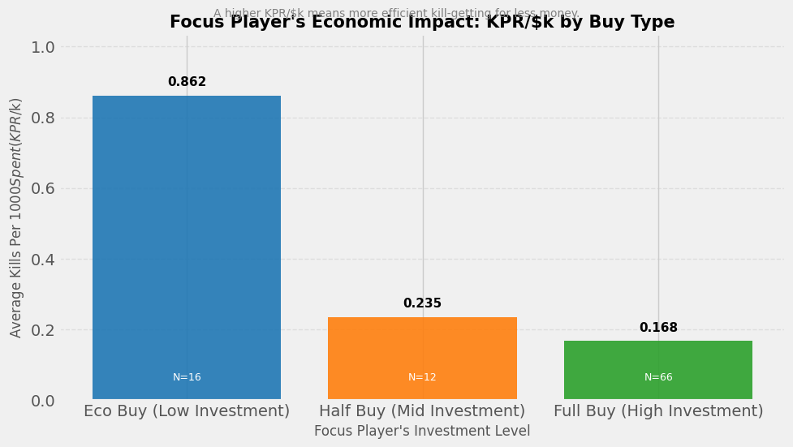

```
--- Investment vs. Impact Analysis Summary ---

Interpretation:
The player's highest economic efficiency (best KPR/$k) is during the 'Eco Buy (Low Investment)' rounds.
```

```python
rain_data['equip_value_k'] = rain_data['fp_equip_value'] / 1000


rain_data['kpr_per_k_spent'] = rain_data.apply(
    lambda row: row['fp_kills'] / row['equip_value_k'] if row['equip_value_k'] > 0 else 0,
    axis=1
)


def classify_fp_buy(value):
    if value < 1800:
        return 'Eco Buy (Low Investment)'
    elif value <= 3500:
        return 'Half Buy (Mid Investment)'
    else:
        return 'Full Buy (High Investment)'

rain_data['fp_buy_type'] = rain_data['fp_equip_value'].apply(classify_fp_buy)


analysis_summary = rain_data.groupby('fp_buy_type')['kpr_per_k_spent'].agg(['mean', 'std', 'count']).reset_index()
analysis_summary.columns = ['FP_Buy_Type', 'Avg_KPR_Per_K_Spent', 'Std_Dev', 'Round_Count']


buy_order = ['Eco Buy (Low Investment)', 'Half Buy (Mid Investment)', 'Full Buy (High Investment)']
analysis_summary['FP_Buy_Type'] = pd.Categorical(
    analysis_summary['FP_Buy_Type'],
    categories=buy_order,
    ordered=True
)
analysis_summary = analysis_summary.sort_values('FP_Buy_Type')



plt.style.use('fivethirtyeight')
fig, ax = plt.subplots(figsize=(10, 6))

bars = ax.bar(
    analysis_summary['FP_Buy_Type'],
    analysis_summary['Avg_KPR_Per_K_Spent'],
    color=['#1f77b4', '#ff7f0e', '#2ca02c'],
    alpha=0.9
)


for i, bar in enumerate(bars):
    yval = bar.get_height()
    N = analysis_summary['Round_Count'].iloc[i]

    ax.text(bar.get_x() + bar.get_width()/2, yval + 0.02,
            f'{yval:.3f}', ha='center', va='bottom', fontsize=11, color='black', fontweight='bold')

    ax.text(bar.get_x() + bar.get_width()/2, 0.05,
            f'N={N}', ha='center', va='bottom', fontsize=9, color='white')


ax.set_ylim(0, analysis_summary['Avg_KPR_Per_K_Spent'].max() * 1.2)
ax.set_xlabel("Focus Player's Investment Level", fontsize=12)
ax.set_ylabel('Average Kills Per $1000 Spent (KPR/$k)', fontsize=12)

plt.title(
    "Focus Player's Economic Impact: KPR/$k by Buy Type",
    fontsize=15,
    fontweight='bold'
)
plt.suptitle(
    "A higher KPR/$k means more efficient kill-getting for less money.",
    fontsize=10,
    color='gray',
    y=0.92
)

plt.grid(axis='y', linestyle='--', alpha=0.5)
plt.tight_layout()
plt.show()

print("\n--- Investment vs. Impact Analysis Summary ---")
print("\nInterpretation:")
print(f"The player's highest economic efficiency (best KPR/$k) is during the '{analysis_summary.iloc[analysis_summary['Avg_KPR_Per_K_Spent'].argmax()]['FP_Buy_Type']}' rounds.")
```

Then above graph shows that rain's kill per $1000 is extremely high during his eco/low buy rounds, alluding to him being an economic machine, with the ability to provide huge impact even with cheap gear.

### Positional Analysis

Getting kills is one of the most important things in Counter Strike, knowing this we want to understand how to better get kills or how to prevent deaths. In this section we will analyze rain's positioning throughout the rounds recorded to find his best and worst positions on Ancient.

#### Death Hotspots

This is a crucial analysis for player understanding/improvement. Identifying death hotspots reveals where the player's positioning, awareness, or even aim might be failing them.

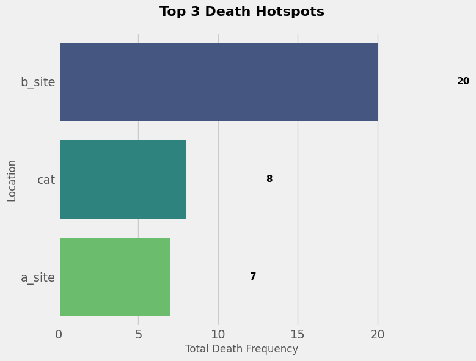

```
--- Summary Data Table ---
```

```python
# 1. Filter the DataFrame to exclude the specified status
filtered_df = rain_data[rain_data['fp_death_loc'] != 'survived']

# 2. Count the occurrences of the remaining locations and get the Top N
location_counts = filtered_df['fp_death_loc'].value_counts()
top_n_hotspots = location_counts.head(3).reset_index()
top_n_hotspots.columns = ['Location', 'Frequency']


# --- 3. Visualization: Horizontal Bar Chart ---

plt.style.use('fivethirtyeight')
fig, ax = plt.subplots(figsize=(10, 6))

# Create the horizontal bar plot
sns.barplot(
    x='Frequency',
    y='Location',
    data=top_n_hotspots,
    palette='viridis',
    ax=ax
)

# Add exact frequency labels to the bars for precision
for i, (freq, location) in enumerate(zip(top_n_hotspots['Frequency'], top_n_hotspots['Location'])):
    ax.text(freq + 5, i, f'{freq}', va='center', fontsize=11, fontweight='bold', color='black')

# --- 4. Final Touches and Layout Adjustment ---

ax.set_title(
    f"Top 3 Death Hotspots",
    fontsize=16,
    fontweight='bold',
    pad=20
)
ax.set_xlabel('Total Death Frequency', fontsize=12)
ax.set_ylabel('Location', fontsize=12)

# Ensure the x-axis starts at zero
ax.set_xlim(0, top_n_hotspots['Frequency'].max() * 1.15)

# Adjust the left margin aggressively to accommodate long location labels
plt.subplots_adjust(left=0.35, right=0.95, top=0.9, bottom=0.1)
plt.show()

print("\n--- Summary Data Table ---")
```

```python
rain_data['fp_death_loc'].value_counts()
```

```
fp_death_loc
survived    37
b_site      20
cat          8
a_site       7
cave         6
b_ramp       5
mid          4
donut        2
ct           2
red_room     2
a_main       1
Name: count, dtype: int64
```

As we see above the most dangerous place in all of ancient for rain is b site, making up 35% of his deaths, this could be because he primarily plays there on ct side so he is put in more situations to die there. Next we will analyze his kill hotspots to see if rain's many deaths on b site are in vain or not.

#### Kill Hotspots

```python
rain_data['fp_kill_4_location'].value_counts()
```

```
fp_kill_4_location
no_kill    93
cave        1
Name: count, dtype: int64
```

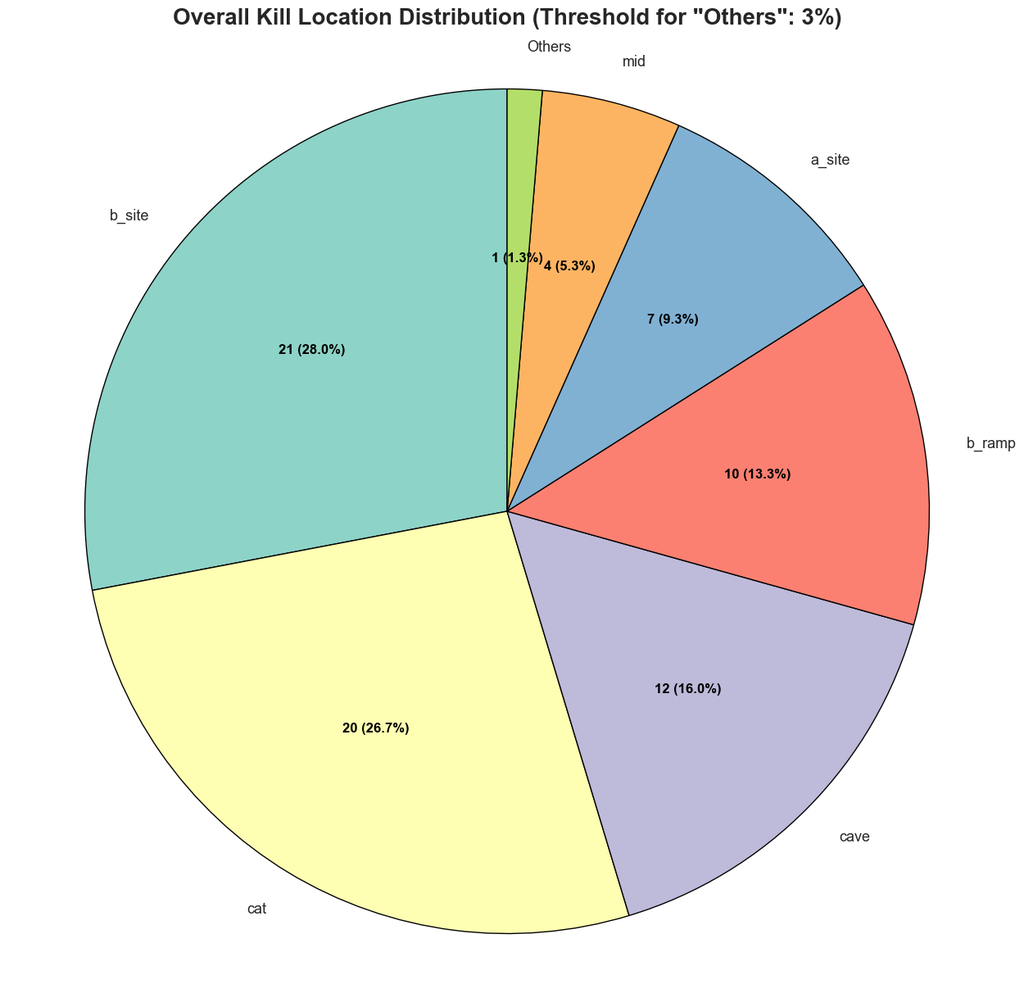

```python
POSSIBLE_LOCATIONS = [
    'cat', 'b_site', 'b_ramp', 'cave', 'a_site', 'mid', 'donut'
]

NO_LOCATION_STR = 'no_kill'

OTHERS_THRESHOLD = 0.03

kill_cols = [col for col in rain_data.columns if 'fp_kill' in col]

rain_data[kill_cols] = rain_data[kill_cols].astype(str).fillna(NO_LOCATION_STR)

melted_df = rain_data.melt(
    id_vars=['fp_side'],
    value_vars=kill_cols,
    value_name='Kill_Location'
)

all_kill_locations = melted_df[melted_df['Kill_Location'].isin(POSSIBLE_LOCATIONS)].copy()

all_kill_counts = all_kill_locations['Kill_Location'].value_counts()
total_valid_kills = all_kill_counts.sum()

kill_percentages = all_kill_counts / total_valid_kills
small_locations = kill_percentages[kill_percentages < OTHERS_THRESHOLD]

if not small_locations.empty:
    others_count = all_kill_counts.loc[small_locations.index].sum()
    top_counts = all_kill_counts.drop(small_locations.index)
    if others_count > 0:
        top_counts['Others'] = others_count
else:
    top_counts = all_kill_counts.copy()

top_counts = top_counts.sort_values(ascending=False)
labels = top_counts.index.tolist()
sizes = top_counts.values.tolist()


plt.style.use('seaborn-v0_8-whitegrid')

kill_counts_iter = iter(sizes)
def kill_count_and_pct(pct):
    absolute_count = next(kill_counts_iter)

    return f'{absolute_count} ({pct:.1f}%)'

fig, ax = plt.subplots(figsize=(14, 14))

colors = plt.cm.Set3.colors

wedges, texts, autotexts = ax.pie(
    sizes,
    labels=labels,
    autopct=kill_count_and_pct,
    startangle=90,
    colors=colors,
    wedgeprops={"edgecolor": "black", 'linewidth': 1, 'antialiased': True}
)

for autotext in autotexts:
    autotext.set_color('black')
    autotext.set_fontsize(12)
    autotext.set_fontweight('bold')
for text in texts:
    text.set_fontsize(13)

ax.axis('equal')

ax.set_title(
    f'Overall Kill Location Distribution (Threshold for "Others": {OTHERS_THRESHOLD*100:.0f}%)',
    fontsize=20,
    fontweight='bold',
    pad=20
)

plt.show()
```

### Overall Effectiveness

We have learned a lot about rain so far, now lets focus on his overall effectiveness and raw impact in influencing round wins. We will look at how important his survival is for the team to win the round, and how significant his kills are in winning rounds.

#### Survival/Death Significance

```python
total_rounds = rain_data.shape[0]

print("="*50)
print(f"SURVIVAL ANALYSIS (Total Rounds: {total_rounds})")
print("="*50)

rounds_died = rain_data['fp_died'].astype(int).sum()
rounds_survived = total_rounds - rounds_died

survival_rate = rounds_survived / total_rounds

print("\n--- 1. Survival Rate ---")
print(f"Rounds Died: {rounds_died} / {total_rounds}")
print(f"Rounds Survived: {rounds_survived}")
print(f"Survival Rate: {survival_rate:.2%} (The percentage of rounds where the player was alive at the end)")


survived_and_won_df = rain_data[(rain_data['fp_died'] == False) & (rain_data['fp_wins_round'] == True)]
survived_and_won_count = survived_and_won_df.shape[0]

clutch_survival_win_rate = survived_and_won_count / total_rounds

win_rate_when_survived = survived_and_won_count / rounds_survived if rounds_survived > 0 else 0


print("\n--- 2.  Survival Win Rate ---")
print(f"Rounds Survived & Won: {survived_and_won_count}")
print(f"Survival Win Rate: {clutch_survival_win_rate:.2%} (Percentage of ALL rounds won while player was alive)")
print(f"Win Rate WHEN Survived: {win_rate_when_survived:.2%} (The chance the team wins IF the player survives)")
```

[output not shown]

#### Kill Significance

This next analysis is on rains kill significance, we are going to look at his average kills in wins minus the average kills in losses to see how important him getting kills is to winning the round.

```python
try:
    rain_data['fp_kills'] = pd.to_numeric(rain_data['fp_kills'], errors='coerce').fillna(0).astype(int)
except Exception as e:
    print(f"Warning: Could not convert 'fp_kills' to integer. Error: {e}")
    # Proceeding with float conversion if int fails
    rain_data['fp_kills'] = pd.to_numeric(rain_data['fp_kills'], errors='coerce')
total_rounds = rain_data.shape[0]

rain_data['Round_Result'] = np.where(
    rain_data['fp_wins_round'] == True,
    'Win',
    'Loss'
)


kill_value_summary = rain_data.groupby('Round_Result')['fp_kills'].agg(['count', 'sum', 'mean', 'std']).reset_index()
kill_value_summary = kill_value_summary.rename(columns={
    'count': 'Rounds',
    'sum': 'Total Kills',
    'mean': 'Avg Kills per Round',
    'std': 'Std Dev of Kills'
})


avg_kills_win = kill_value_summary[kill_value_summary['Round_Result'] == 'Win']['Avg Kills per Round'].iloc[0]
avg_kills_loss = kill_value_summary[kill_value_summary['Round_Result'] == 'Loss']['Avg Kills per Round'].iloc[0]


kill_value_difference = avg_kills_win - avg_kills_loss



print("="*60)
print(f"KILL VALUE & SIGNIFICANCE ANALYSIS (Total Rounds: {total_rounds})")
print("="*60)


print("\n" + "-"*60)
print(f"AVERAGE KILLS IN WINS: {avg_kills_win:.2f}")
print(f"AVERAGE KILLS IN LOSSES: {avg_kills_loss:.2f}")
print(f"KILL VALUE DIFFERENCE (Win Avg - Loss Avg): {kill_value_difference:.2f}")
print("-"*60)


print("\n--- Interpretation: Kill Significance ---")

if kill_value_difference > 0.1:
    print(f"The Focus Player averages {kill_value_difference:.2f} **more kills** in rounds their team WINS.")
    print("This indicates a **High Kill Value**. Their kills are highly significant, meaning they are likely:")
    print("1. Securing crucial **entry kills** or mid-round kills that directly create a team advantage.")
    print("2. The source of the necessary firepower to close out competitive rounds.")
elif kill_value_difference < -0.1:
    print(f"The Focus Player averages {abs(kill_value_difference):.2f} **fewer kills** in rounds their team WINS.")
    print("This indicates a **Low Kill Value**.")
    print("1. They might be getting many 'junk kills' or exit frags after the round is already lost.")
    print("2. While their output is high, it is not strongly correlated with team success.")
else:
    print("The average kills in Wins and Losses are nearly identical.")
    print("This suggests their kill output is **highly consistent** but doesn't necessarily spike during successful rounds.")
```

```
============================================================
KILL VALUE & SIGNIFICANCE ANALYSIS (Total Rounds: 94)
============================================================

------------------------------------------------------------
AVERAGE KILLS IN WINS: 1.10
AVERAGE KILLS IN LOSSES: 0.41
KILL VALUE DIFFERENCE (Win Avg - Loss Avg): 0.69
------------------------------------------------------------

--- Interpretation: Kill Significance ---
The Focus Player averages 0.69 **more kills** in rounds their team WINS.
This indicates a **High Kill Value**. Their kills are highly significant, meaning they are likely:
1. Securing crucial **entry kills** or mid-round kills that directly create a team advantage.
2. The source of the necessary firepower to close out competitive rounds.
```

"The numbers, Mason, what do they mean?" Well the numbers don't lie here, rain is extremely obviously a high impact kill player. Boasting an average 1.1 kills per winning round and getting 0.69 more kills than on losing rounds indicates that when he gets kills he wins rounds.

## Conclusion: Rain is The Apex of Impact and Adaptability

His skill set is crazy versatile, too. You can put him in any spot on the map, and he'll master it. And the best part is his adaptability: give him a rifle, a pistol, or even just high-fives, and he'll find a way to make it work. He never lets the gear be an excuse; he just performs.

But what truly makes him amazing are the qualities that don't show up on the scoreboard. He’s the quintessential “best teammate.” He’s the rock, the morale booster, and the guy who holds everything together when the pressure is boiling over. Rain isn’t just a great player; he’s the necessary glue that makes his team elite.